# Lab 05: - Tempe Accident Analysis

Anna Hall

March 29, 2023

# Setup

The following analysis uses data comprised of traffic accidents in the city of Tempe, Arizona. They constitute 28,470 observations and 32 variables. You can find more details in the dataset documentation at the [**Tempe Open Data Portal**](https://data.tempe.gov/dataset/high-severity-traffic-crashes-1-08).

Explore the first six observations in the following interactive table:

```r
head(dat)
```

|  | Incidentid | DateTime | Year | StreetName | CrossStreet | Distance | JunctionRelation | Totalinjuries | Totalfatalities | Injuryseverity | Collisionmanner | Lightcondition | Weather | SurfaceCondition | Unittype_One | Age_Drv1 | Gender_Drv1 | Traveldirection_One | Unitaction_One | Violation1_Drv1 | AlcoholUse_Drv1 | DrugUse_Drv1 | Unittype_Two | Age_Drv2 | Gender_Drv2 | Traveldirection_Two | Unitaction_Two | Violation1_Drv2 | AlcoholUse_Drv2 | … |
| --- | --- | --- | --- | --- | --- | --- | --- | --- | --- | --- | --- | --- | --- | --- | --- | --- | --- | --- | --- | --- | --- | --- | --- | --- | --- | --- | --- | --- | --- | --- |
| 1 | 2579417 | 1/10/12 9:04 | 2012 | Baseline Rd | Price Rd | -24.816 | Intersection Related Interchange | 0 | 0 | No Injury | Rear End | Daylight | Clear | Dry | Driver | 43 | Male | East | Going Straight Ahead | Inattention Distraction | No Apparent Influence | No Apparent Influence | Driver | 62 | Male | East | Going Straight Ahead | No Improper Action | No Apparent Influence | … |
| 2 | 2582044 | 1/5/12 17:24 | 2012 | Rural Rd | Playa Del Norte | -796.224 | Not Junction Related | 0 | 0 | No Injury | Rear End | Dusk | Clear | Dry | Driver | 19 | Male | North | Going Straight Ahead | Speed To Fast For Conditions | No Apparent Influence | No Apparent Influence | Driver | 28 | Male | North | Stopped In Trafficway | No Improper Action | No Apparent Influence | … |
| 3 | 2582996 | 1/16/12 19:08 | 2012 | Rio Salado Pkwy | State Route 101 Exit 51 J-Ramp | 0.000 | Intersection Interchange | 0 | 0 | No Injury | ANGLE (Front To Side)(Other Than Left Turn) | Dark Lighted | Clear | Dry | Driver | 26 | Male | North | Making Left Turn | Made Improper Turn | No Apparent Influence | No Apparent Influence | Driver | 24 | Male | West | Going Straight Ahead | No Improper Action | No Apparent Influence | … |
| 4 | 2584311 | 1/27/12 14:41 | 2012 | Rio Salado Pkwy | State Route 101 Exit 51 J-Ramp | 76.032 | Not Junction Related | 1 | 0 | Possible Injury | Rear End | Daylight | Cloudy | Dry | Driver | 29 | Male | West | Going Straight Ahead | Speed To Fast For Conditions | No Apparent Influence | No Apparent Influence | Driver | 18 | Female | West | Stopped In Trafficway | No Improper Action | No Apparent Influence | … |
| 5 | 2584437 | 1/10/12 13:41 | 2012 | Scottsdale Rd | State Route 202 Exit 7 P-Ramp | -40.128 | Entrance Exit Ramp Interchange | 0 | 0 | No Injury | Rear End | Daylight | Clear | Dry | Driver | 255 |  | North | Going Straight Ahead | Speed To Fast For Conditions | No Apparent Influence | No Apparent Influence | Driver | 26 | Male | North | Stopped In Trafficway | No Improper Action | No Apparent Influence | … |
| 6 | 2584439 | 1/9/12 17:49 | 2012 | Priest Dr | 12th St | 70.224 | Not Junction Related | 0 | 0 | No Injury | Sideswipe Same Direction | Dark Lighted | Clear | Unknown | Driver | 255 |  | Unknown | Unknown | Unknown | No Apparent Influence | No Apparent Influence | Driver | 31 | Female | South | Going Straight Ahead | No Improper Action | No Apparent Influence | … |

# Preprocessing

All data preprocessing are available in **Appendix Code A: Data Preprocessing**.

# Part I: Data Summaries

The following provides brief exploratory summaries on key data points.

## 1. Accidents on Mondays

```r
x <- sum(dat$day == "Mon",
         na.rm = TRUE)

comma(x)                    # Example solution
```

```
## [1] "4,094"
```

** 4,094 ** accidents occurred on Mondays.

## 2. Monday Accidents (%)

```r
x <- mean(dat$day == "Mon",
         na.rm = TRUE)

percent(x)
```

```
## [1] "14%"
```

```r
# Code
```

**[14.4]%** of all accidents occur on Mondays.

## 3. Harmful Monday Accidents (%)

**Note:** *“Harm” is defiend as any accident that causes at least one injury or* *fatality, i.e. a casualty.*

```r
# Code

mond.dat <- dat %>% filter(dat$day == "Mon")
harm.mond <- mean(mond.dat$Totalinjuries > 0 |
  mond.dat$Totalfatalities  > 0, na.rm = T) * 100

(harm.mond)
```

```
## [1] 29.84856
```

**[29.85]%** of all Monday accidents have at least one casualty.

## 4. Top Monday Accident Type

```r
dat %>%
  filter(day == "Mon") %>%
  count(Collisionmanner) %>%
  arrange(desc(n))
```

| Collisionmanner | n |
| --- | --- |
| Rear End | 1566 |
| Left Turn | 733 |
| ANGLE (Front To Side)(Other Than Left Turn) | 707 |
| Sideswipe Same Direction | 535 |
| Single Vehicle | 225 |
| Other | 171 |
| Unknown | 47 |
| Head On | 44 |
| Rear To Side | 29 |
| Sideswipe Opposite Direction | 29 |

[output cut: 1 more lines]

**Rear Ends** collisions are the most common accident types.

## 5. Week vs. Weekend Accidents

```r
# Code

dat %>%
  group_by(day) %>%
  summarize(accidents = comma(n()))
```

| day | accidents |
| --- | --- |
| Mon | 4,094 |
| Tue | 4,656 |
| Wed | 4,711 |
| Thu | 4,814 |
| Fri | 5,006 |
| Sat | 3,044 |
| Sun | 2,145 |

Significantly more accidents occur **[on weekdays]**.

## 6. Harm by Weekday

```r
dat %>%
  group_by(day) %>%
  mutate(harm_acc = Totalinjuries > 0 | Totalfatalities > 0) %>%
  summarize(n = n(),
            injuries = sum(Totalinjuries),
            fatalities = sum(Totalfatalities),
            harm.rate = mean(harm_acc))
```

| day | n | injuries | fatalities | harm.rate |
| --- | --- | --- | --- | --- |
| Mon | 4094 | 1644 | 13 | 0.2984856 |
| Tue | 4656 | 2056 | 8 | 0.3228093 |
| Wed | 4711 | 2144 | 9 | 0.3147952 |
| Thu | 4814 | 2204 | 10 | 0.3269630 |
| Fri | 5006 | 2103 | 12 | 0.2958450 |
| Sat | 3044 | 1192 | 11 | 0.2644547 |
| Sun | 2145 | 866 | 6 | 0.2685315 |

# Part II: Age Groups

The following provides summaries of accidents by age groups.

## 1. Accidents by Hour & Age

```r
dat %>%
  filter(hour == "07") %>%
  group_by(age) %>%
  mutate(harm_acc = Totalinjuries > 0 | Totalfatalities > 0) %>%
   summarize(n = n(),
            injuries = sum(Totalinjuries),
            fatalities = sum(Totalfatalities),
            harm.rate = mean(harm_acc))
```

| age | n | injuries | fatalities | harm.rate |
| --- | --- | --- | --- | --- |
| Age 16-18 | 77 | 26 | 0 | 0.2727273 |
| Age 18-25 | 408 | 190 | 0 | 0.3406863 |
| Age 25-35 | 371 | 155 | 0 | 0.2938005 |
| Age 35-45 | 243 | 98 | 2 | 0.2921811 |
| Age 45-55 | 175 | 60 | 0 | 0.2742857 |
| Age 55-65 | 116 | 62 | 0 | 0.3534483 |
| Age 65-75 | 39 | 20 | 0 | 0.3333333 |
| Age 75-100 | 17 | 14 | 0 | 0.3529412 |
| NA | 160 | 57 | 0 | 0.2750000 |

```r
# Code
```

Drivers of **[Age 18-25]** have the greatest number of accidents from 7:00 to 7:59 AM.

# Part III: Rates of Harm

The following reports the accidents, casualties, proportion, and average casualties per harmful accident.

## 1. Accidents by Hour

```r
dat %>%
  group_by(hour) %>%
 summarize(Accidents = number(n(),
                               big.mark = ","))      # Example solution
```

| hour | Accidents |
| --- | --- |
| 00 | 388 |
| 01 | 289 |
| 02 | 362 |
| 03 | 190 |
| 04 | 125 |
| 05 | 300 |
| 06 | 647 |
| 07 | 1,606 |
| 08 | 1,519 |
| 09 | 1,066 |

[output cut: 14 more lines]

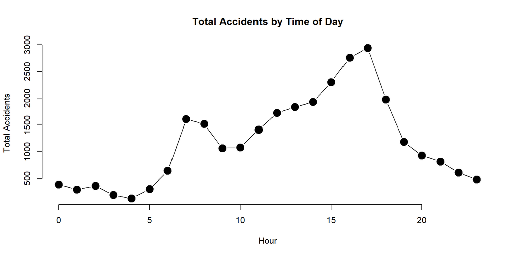

```r
dat %>%
  group_by(hour) %>%
  summarize(n = n()) %>%
  plot(type = "b",
       bty = "n",
       pch = 19,
       cex = 2,
       xlab = "Hour",
       ylab = "Total Accidents",
       main = "Total Accidents by Time of Day")
```

## 2. Total Casualties by Hour

```r
dat %>%
  group_by(hour) %>%
  summarize(harm_acc = Totalinjuries > 0 & Totalfatalities > 0)     # Example solution
```

[output not shown]

[output cut: 9990 more lines]

[figure not shown]

```r
dat %>%
  group_by(hour) %>%
  summarize(n = n()) %>%
  plot(type = "b",
       bty = "n",
       pch = 19,
       cex = 2,
       xlab = "Hour",
       ylab = "Total Casualities",
       main = "Total Casualities by Time of Day")
```

```r
# Code
```

## 3. Accidents with Casualties (%)

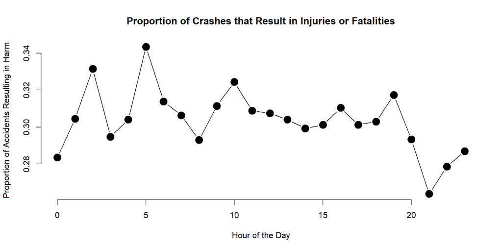

```r
dat %>%
  mutate(casuality = ifelse(Totalinjuries + Totalfatalities > 0, T, F)) %>%
  group_by(hour) %>%
  summarize(proportion = mean (casuality)) %>%
  plot(type = "b",
       bty = "n",
       pch = 19,
       cex = 2,
       xlab = "Hour of the Day",
       ylab = "Proportion of Accidents Resulting in Harm",
       main = "Proportion of Crashes that Result in Injuries or Fatalities")
```

```r
# Code
```

## 4. Mean Casualties/Harmful Accident

[figure not shown]

```r
dat %>%
  filter(Totalinjuries > 0 | Totalfatalities > 0) %>%
  mutate(casuality = Totalinjuries + Totalfatalities) %>%
  group_by(hour) %>%
  summarize(average = round(sum(casuality)/ n( ), 3)) %>%
  plot(type = "b",
       bty = "n",
       pch = 19,
       cex = 2,
       xlab = "Hour of the Day",
       ylab = "Average Number of Passengers Hurt",
       main = "Proportion of Injuries or Fatalities per Harmful Crash")
```

```r
# Code
```

# Appendix

## Code A: Data Preprocessing

```r
date.vec <- strptime(dat$DateTime,
                     format = "%m/%d/%y %H:%M")   # Create date fields

dat$hour   <- format(date.vec, format = "%H")
dat$month  <- format(date.vec, format = "%b")
dat$day    <- format(date.vec, format = "%a")
dat$day365 <- format(date.vec, format = "%j")
dat$week   <- format(date.vec, format = "%V")

dat$day <- factor(dat$day,
                  levels = c("Mon",
                             "Tue",
                             "Wed",
                             "Thu",
                             "Fri",
                             "Sat",
                             "Sun"))              # Order weekdays

dat$hour12 <- format(date.vec,
                     format="%l %p")              # Create 12-hour format

time.levels <- c("12 AM", " 1 AM", " 2 AM", " 3 AM", " 4 AM", " 5 AM",
                 " 6 AM", " 7 AM", " 8 AM", " 9 AM", "10 AM", "11 AM",
                 "12 PM", " 1 PM", " 2 PM", " 3 PM", " 4 PM", " 5 PM",
                 " 6 PM", " 7 PM", " 8 PM", " 9 PM", "10 PM", "11 PM" )

dat$hour12 <- factor(dat$hour12,
                     levels = time.levels)        # Order time intervals

age.labels <- paste0("Age ",
                     c(16,18,25,35,45,55,65,75), "-",
                     c(18,25,35,45,55,65,75,100) )

dat$age <- cut(dat$Age_Drv1,
               breaks = c(16,18,25,
                          35,45,55,
                          65,75,100),
               labels = age.labels)               # Discretize age ranges
```